# Cell type calling for spatial transcriptomics (spaceTx) data - smFISH and scRNAseq

Yun (Renee) Zhang, zhangy@jcvi.org

December 02, 2021

Quick facts about the datasets:

- Reference data
  - Anatomic region: healthy mouse primary visual cortex (VISp)
  - Protocol: single cell RNA sequencing (scRNAseq)
  - Citation: [Shared and distinct transcriptomic cell types across neocortical areas](https://www.nature.com/articles/s41586-018-0654-5)
- Query data
  - Anatomic region: healthy mouse primary visual cortex (VISp)
  - Protocol: smFISH spatial transcriptomics
  - Citation: [SpaceTx](https://spacetx-website.github.io/)

```r
library(tidyverse)
library(FRmatch)
library(SingleCellExperiment)
library(viridis)
```

# Data

## Pre-clustering of spatial data

The smFISH data is pre-clustered following the SCANPY pipeline using Leiden clustering with resolution 0.8, which resulted in 16 smFISH clusters shown in a UMAP below.

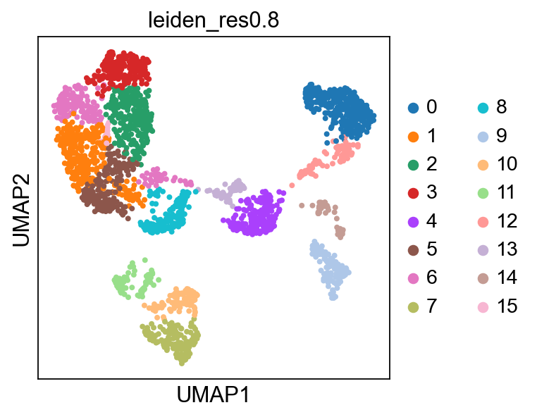

smFISH clusters

## Load data objects

Load pre-made data objects. See [here](https://jcventerinstitute.github.io/celligrate/FRmatch-vignette.html) to construct your own data object. The markers in this case will be the smFISH probe genes.

```r
load("~/Documents/SpaceTx-2020/Data/dat-smFISH-filtered-cluster.rda")
load("~/Documents/SpaceTx-2020/Data/dat-scRNA-smFISHprobes.rda")
ls()
```

```
[1] "sce.scRNA"  "sce.smFISH"
```

Check the gene exprresion distribution from the two assays. The density plots showed very different data range and distributional property.

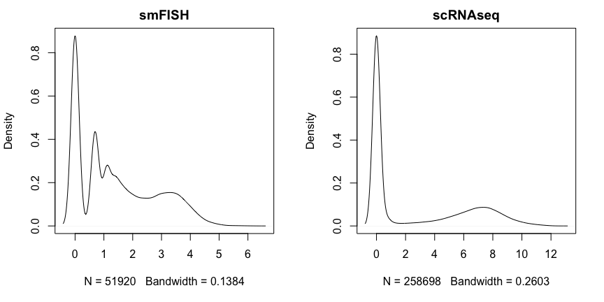

```r
par(mfrow=c(1,2))
plot(density(assay(sce.smFISH)), main="smFISH")
plot(density(assay(sce.scRNA)), main="scRNAseq")
```

## Normalization

Use the built-in normalization function in FR-Match to align the distributions.

```r
sce.scRNA.norm <- normalization(sce.scRNA)
sce.smFISH.norm <- normalization(sce.smFISH, norm.by = "mean")
```

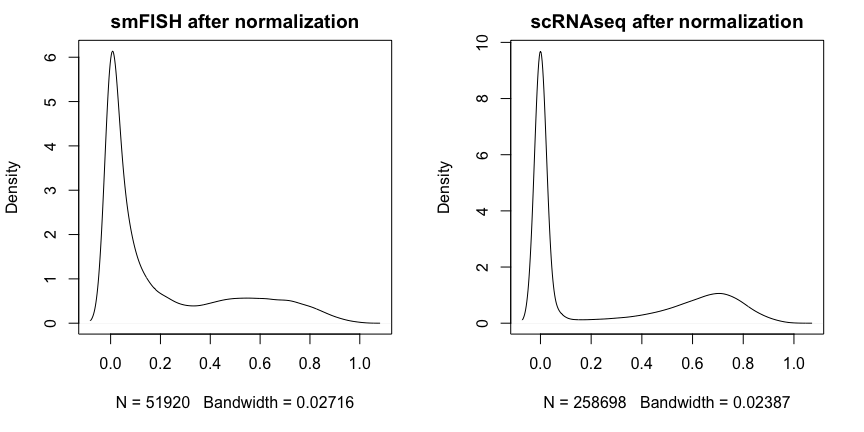

```r
par(mfrow=c(1,2))
plot(density(assay(sce.smFISH.norm)), main="smFISH after normalization")
plot(density(assay(sce.scRNA.norm)), main="scRNAseq after normalization")
```

Note that, in our gene by gene examination, we noticed that the sensitivity of the Kcnip4 probe gene in smFISH was low (i.e. noise-like weak expression), therefore we remove this probe gene in our analysis.

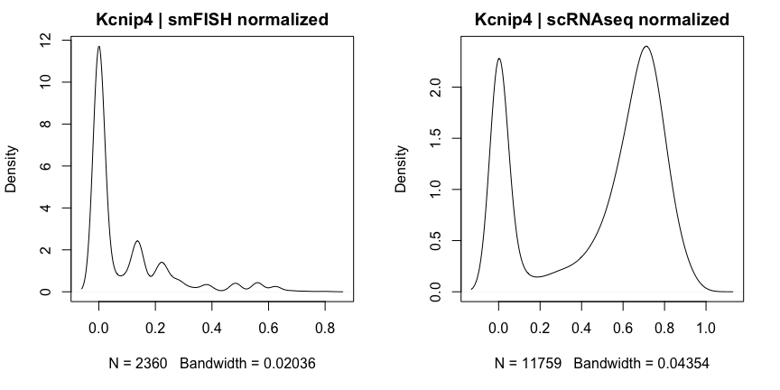

```r
par(mfrow=c(1,2))
plot(density(assay(sce.smFISH.norm)["Kcnip4",]), main="Kcnip4 | smFISH normalized")
plot(density(assay(sce.scRNA.norm)["Kcnip4",]), main="Kcnip4 | scRNAseq normalized")
```

```r
rowData(sce.smFISH.norm)["Kcnip4",] <- 0
rowData(sce.scRNA.norm)["Kcnip4",] <- 0
```

# FR-Match (cell2cluster)

```r
myrst <- FRmatch_cell2cluster(sce.smFISH.norm, sce.scRNA.norm,
                              filter.size=5, subsamp.size=10, subsamp.iter=1e3)
```

## Plot the results

Preparing for spatial plot.

```r
## spatial coordinates
coord <- read.csv("~/Documents/SpaceTx-2020/Data/smFISH_filtered/smFISH_filtered_metadata.csv") %>%
  select(sample_name, rotated_x, rotated_y) %>% mutate(cell=as.character(sample_name), x=rotated_x, y=rotated_y) %>%
  select(cell, x, y)
## order query (smFISH) clusters based on SCANPY dendrogram
query.cluster.levels <- paste0("query.",c("15","11","7","10","0","12","9","14",
                                          "2","3","6","1","5","4","8","13"))
## scRNA cluster map between consensus clusters and subclasses
sumtab.clusters <- data.table::fread("~/Documents/SpaceTx-2020/Data/snRNAseq/mouseVISp_cluster_summary.csv")
scRNA.cluster.map <- sumtab.clusters %>% select(consensus_cluster, subclass, broad_class) %>% distinct() %>%
  filter(!(consensus_cluster=="cl12_i155_Crabp1_Sncg"&subclass=="Lamp5"))
```

Here, we used a **bottom-up** strategy to summarize the cell type calling at the subclass level. The granularity of the scRNAseq data is high, which resulted in 191 consensus cell types corresponding to 22 cell subclasses.

```r
df.myrst <- myrst$cell2cluster %>% mutate(match=gsub("ref.","",match))
df <- inner_join(coord, df.myrst, by=c("cell"="query.cell")) %>%
  mutate(query.cluster = factor(query.cluster, levels = query.cluster.levels)) %>%
  left_join(scRNA.cluster.map, by=c("match"="consensus_cluster")) #bottom-up cluster map
```

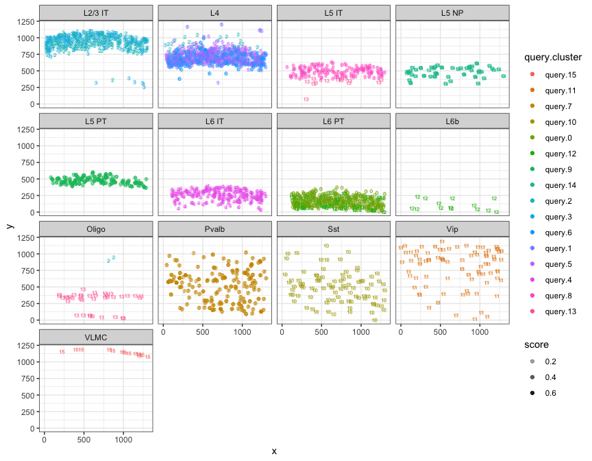

```r
## plot subclass
g <- ggplot(df, aes(x=x, y=y, col=query.cluster, label=gsub("query.","",query.cluster))) +
  geom_point(aes(alpha=score)) + geom_text(size=2) +
  xlim(min(df$x)-1, max(df$x)+1) + ylim(min(df$y)-1, max(df$y)+1) +
  theme_bw() +
  facet_wrap(~ subclass, ncol=4)
g
```

**Conclusion:**

- Major glutamatergic subclasses are in the expected layers; major GABAergic subclasses also reflect the expected laminar pattern.
- FR-Match is able to merge the over-partitioned query clusters, e.g. L4 plot, to the same reference cluster.
- Matched cells to the glial types (Oligo, VLMC) are questionable. It seems that the glial types attracts all weak cells probably due to the gene panel design. More investigations needed.